# Evaluating Recommenders

Shyam BV

July 1, 2017

## Project Description

The goal of this assignment is give you practice working with accuracy and other recommender system metrics. In this assignment you’re asked to do at least one or (if you like) both of the following:

• Work in a small group, and/or

• Choose a different dataset to work with from your previous projects.

Deliverables

1. As in your previous assignments, compare the accuracy of at least two recommender system algorithms against your offline data.
2. Implement support for at least one business or user experience goal such as increased serendipity, novelty, or diversity.
3. Compare and report on any change in accuracy before and after you’ve made the change in #2.
4. As part of your textual conclusion, discuss one or more additional experiments that could be performed and/or metrics that could be evaluated only if online evaluation was possible. Also, briefly propose how you would design a reasonable online evaluation environment.

You’ll find some of the material discussed in this week’s reading to be helpful in completing this project. You may also want to look at papers online, or search for “recsys” on youtube or slideshare.net.

## Dataset

For this assignment, I will be using Movies ratings dataset. This provides extensive ratings from users for different movies. Below link contains detailed information about the dataset.

Dataset Link: https://grouplens.org/datasets/movielens/

## Data Import

```r
ratings_na <- read.csv("data/ratings.csv",sep=",",header=TRUE) %>% select(-timestamp) %>% spread(movieId,rating)  %>% select(-userId) %>% as.matrix()

movie <- ratings_na %>% as("realRatingMatrix")
```

## Data Exploration

Explore the movies dataset with different chart types and see which has the highest ratings.

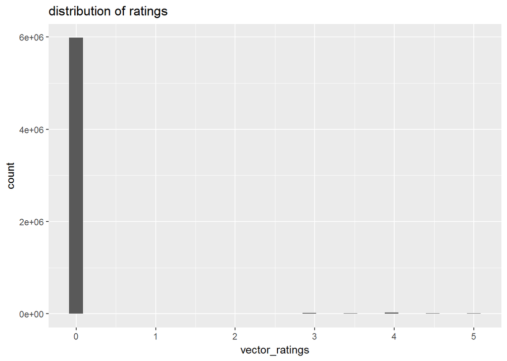

```r
vector_ratings <- as.vector(movie@data)

#Clearly the distribution has many 0 or missing ratings
qplot(vector_ratings) + ggtitle("distribution of ratings")
```

```r
#Table count
table(vector_ratings)
```

```
## vector_ratings
##       0     0.5       1     1.5       2     2.5       3     3.5       4
## 5983282    1101    3326    1687    7271    4449   20064   10538   28750
##     4.5       5
##    7723   15095
```

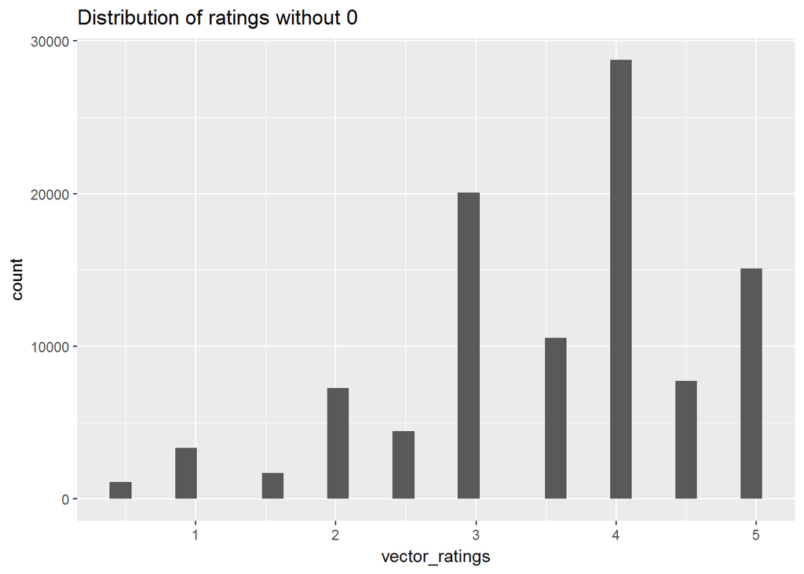

```r
vector_ratings <- vector_ratings[vector_ratings !=0]

qplot(vector_ratings) + ggtitle("Distribution of ratings without 0")
```

### Average ratings by each user

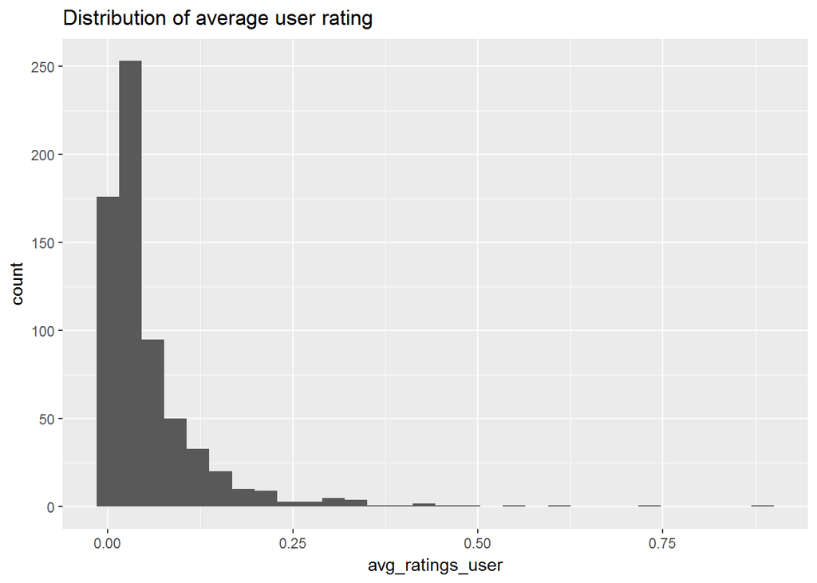

```r
avg_ratings_user <- rowMeans(movie@data)

qplot(avg_ratings_user) + stat_bin(binwidth = .01) + ggtitle("Distribution of average user rating")
```

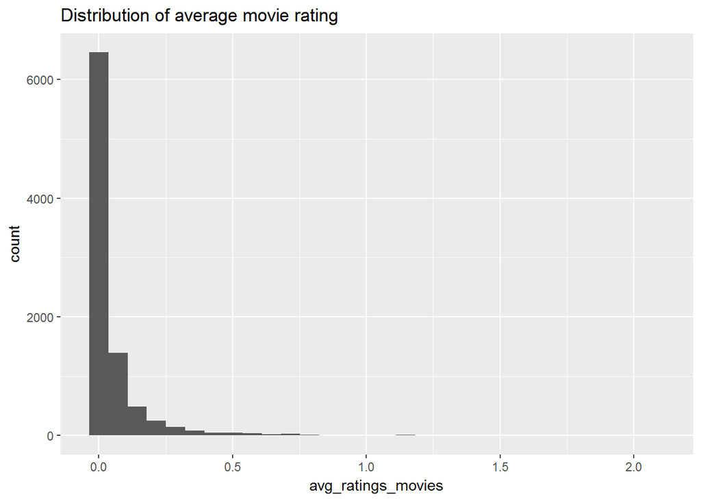

```r
avg_ratings_movies <- colMeans(movie@data)

qplot(avg_ratings_movies) + stat_bin(binwidth = .01) + ggtitle("Distribution of average movie rating")
```

## Data Preparation

Filter the dataset which has some decent ratings.

```r
movies_ratings <- movie[rowCounts(movie) > 30, colCounts(movie) > 80]
```

## Data modelling

### Handelling missing values

Below is the helper function for baseline predictor for missing values

```r
baseline_predictor = function(df,train_raw_mean) {

#User bias: means of each user - raw mean
user_mean =  c(rowMeans(df,na.rm=TRUE)-train_raw_mean)

#book bias: means of each book- raw mean
movie_mean = c(colMeans(df,na.rm=TRUE)-train_raw_mean)

temp_df = data.frame()

for(i in 1:nrow(df)){

  #add all the user and book bias
  final_bias <- train_raw_mean+ user_mean[i] +movie_mean
  temp_df <- rbind(temp_df,final_bias)

}

#Set temp names
temp_df = setNames(temp_df, c(1:ncol(temp_df))) %>% data.frame()

temp_df[is.na(temp_df)] = train_raw_mean


#Return the baseline predicted value
return(temp_df)
}
```

Missing values can be calculacuted using different methods given below.

```r
missingval <- function(umatrix, method) {


if(method == "mean"){

  train_raw_mean <- mean(umatrix,na.rm = TRUE)
  umatrix[is.na(umatrix)] = train_raw_mean

}

else if(method =="mean_center"){
    train_raw_mean <- mean(umatrix,na.rm = TRUE)
  umatrix[is.na(umatrix)] = train_raw_mean

  umatrix <- scale(umatrix ,center = T,scale=F) %>% as.matrix()
}
else if(method=="withna"){
  umatrix <- umatrix

}
else if (method == "baseline"){

    train_raw_mean <- mean(umatrix,na.rm = TRUE)
  umatrix <- baseline_predictor(umatrix,train_raw_mean) %>% as.matrix()

}

  return(umatrix)
}
```

### Training and test dataset

Below function helps to split the the training and test dataset.

```r
percentage_training <- 0.8
items_to_keep <- 2
rating_threshold <- 3
n_eval <- 1
n_fold <- 4

evaluationmethod <- function(umatrix, method ) {

if(method == "split"){

  eval_sets <- evaluationScheme(data = umatrix, method =
                                "split", train = percentage_training, given = items_to_keep,
                              goodRating = rating_threshold, k = n_eval)

}
  else if(method =="bootstrap"){

     eval_sets <- evaluationScheme(data = umatrix, method =
                                "bootstrap", train = percentage_training, given = items_to_keep,
                              goodRating = rating_threshold, k = n_eval)

  }
  else if(method =="cv"){

     eval_sets <- evaluationScheme(data = umatrix, method = "cross-validation", k = n_fold, given = items_to_keep, goodRating = rating_threshold)


  }
return(eval_sets)

}
```